# NDVI_Models

Matt Webster

2026-07-28

The purpose of this RMarkdown is to implement hierarchical generalized linear mixed effects models for NDVI ~ damPresence, & NDVI ~ damDensity (with and without geomorphic covariates). Structurally parallel to VegArea ~ dam models.

4 models total.

```
WAIC indicates that all four models perform comparably well. Given this, I only include code and results for m4, which models the effect of dam density on NDVI, conditional on geomorphic covariates.
```

**HGLMM**

```
This analysis explores late August vegetation greenness (NDVI) in relation to
beaver dam presence, & density.

2 models for dam presence (1 without geomorphic covariates; 1 with geomorphic covariates)
2 models for dam density (...^^^...)

All 4 models presented herein are constructed in a hierarchical generalized linear
mixed effects model framework with stream, year, and cluster_ID as random intercepts
for NDVI.

  - NDVI ~ damPresence (no geom.covar.)
  - NDVI ~ damPresence (geom.covar.)
  - NDVI ~ damDensity (no geom.covar.)
  - NDVI ~ damDensity (no geom.covar.)

Model structure is paralleled with HGLMMs for veg area.

Uses mean(NDVI) for each sample window for 6 watersheds, 3 years, 08/15-08/31
```

**Final Data:**

NOTE: This ONLY uses data from 08/15-08/31. This is to avoid issues with pseudo-replication after the omission of random effects for sample event.

Modeling reflects late August effect of beaver dams on NDVI. Green riparian vegetation = mesic resource that is critical for grouse recruitment.

```
## 'data.frame':    676 obs. of  26 variables:
##  $ X               : int  2 6 10 14 18 22 26 30 34 38 ...
##  $ clusterID_seq   : int  1 1 3 3 4 4 5 5 6 6 ...
##  $ window_type     : chr  "dammed" "undammed" "dammed" "undammed" ...
##  $ watershed       : chr  "WC" "WC" "WC" "WC" ...
##  $ year            : int  2019 2019 2019 2019 2019 2019 2019 2019 2019 2019 ...
##  $ catchment_km2   : num  1394 1391 1383 1383 1364 ...
##  $ TO              : num  34.2 35.7 33.2 33.1 45.6 ...
##  $ Nhat            : num  1.13 0 1.13 0 1.13 ...
##  $ t               : int  6 6 6 6 6 6 6 6 6 6 ...
##  $ surveyPeriod    : int  196 196 196 196 196 196 196 196 196 196 ...
##  $ SWA             : num  0 66.7 133.2 332.6 1732.6 ...
##  $ VA              : num  17732 15430 14613 14859 10717 ...
##  $ NDVI            : num  0.359 0.37 0.39 0.347 0.381 ...
##  $ riparian_area_m2: num  2678 2766 2551 2523 3883 ...
##  $ dam_km          : num  4.53 0 4.51 0 4.52 ...
##  $ clusterID_unique: chr  "2019.WC.1" "2019.WC.1" "2019.WC.3" "2019.WC.3" ...
##  $ clusterID_num   : int  16 16 34 34 43 43 52 52 61 61 ...
##  $ stream          : int  6 6 6 6 6 6 6 6 6 6 ...
##  $ sampleEvent     : int  2 2 2 2 2 2 2 2 2 2 ...
##  $ year_id         : int  1 1 1 1 1 1 1 1 1 1 ...
##  $ damPresence     : int  1 0 1 0 1 0 1 0 1 0 ...
##  $ sampleEvent_new : int  2 2 2 2 2 2 2 2 2 2 ...
##  $ logSWA          : num  0 4.21 4.9 5.81 7.46 ...
##  $ y               : int  0 1 1 1 1 1 1 1 1 1 ...
##  $ y_veg           : int  1 1 1 1 1 1 1 1 1 1 ...
##  $ dam_km_std      : num  0.499 -0.94 0.495 -0.94 0.498 ...
```

```
Rough normality of NDVI distribution does not require response variable transformation prior
to modeling.
```

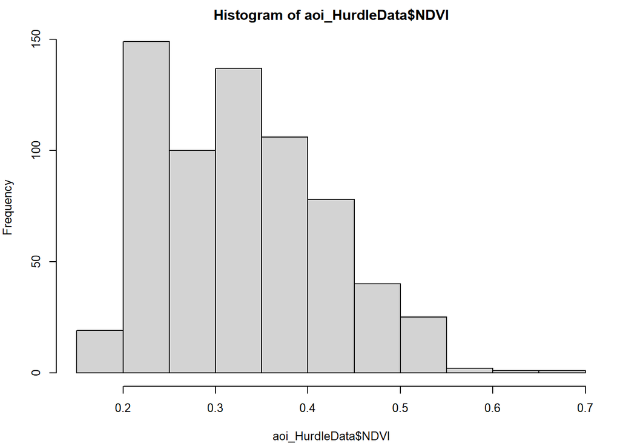

For NDVI models, data of interest include:

```
 - NDVI: average NDVI for sample window[i]; response variable

- stream: index for random intercept on NDVI

- year: index for random intercept on NDVI

- clusterID_seq: index for random intercept on NDVI; represents sample pairing

- damPres: dam presence (0,1); fixed effect on NDVI

- damDen: dams/km; z-standardized ("...$dam_km_std"); fixed effect on NDVI

Only used in models 2 and 4:

- incis: channel incision: 1-(TO/90) (inverse of topographic openness); z-standardized;
  fixed effect on NDVI

- RIPA: riparian area (m^2); z-standardized; fixed effect on NDVI

- UDA: upstream drainage area (km ^2); z-standardized; fixed effect on NDVI
```

**Overall Takeaways**

[output not shown]

## NDVI ~ Dam Presence

**Model 1: NDVI ~ DamPresence**

Effect of damPresence without geomorphic covariates

```
sink("HGLMM_m1_NDVI_damPres.jags")

cat("
model{

  # HYPERPRIORS FOR NDVI (1/2 Normal on SDs):

  sigma ~ dnorm(0,1) T(0,)
  tau <- pow(sigma, -2)

  sigma_eta_stream ~ dnorm(0,1) T(0,)
  tau_eta_stream <- pow(sigma_eta_stream,-2)

  sigma_eta_year ~ dnorm(0,1) T(0,)
  tau_eta_year <- pow(sigma_eta_year,-2)

  sigma_eta_cluster ~ dnorm(0,1) T(0,)
  tau_eta_cluster <- pow(sigma_eta_cluster,-2)

  ##########################################################################
  # RANDOM EFFECT PRIORS:

  for(j in 1:n_stream){
    eta_stream[j]  ~ dnorm(0, tau_eta_stream)
  }

  for(j in 1:n_year){
    eta_year[j] ~ dnorm(0, tau_eta_year)
  }

  for(j in 1:n_cluster){
    eta_cluster[j] ~ dnorm(0, tau_eta_cluster)
  }

  ##########################################################################
  # FIXED EFFECT PRIORS:

  alpha ~ dnorm(0.32,0.04)          # within 5 SD of empirical mean NDVI
  beta_damPres ~ dnorm(0,0.04)

  ##########################################################################

  # MAIN LOOP: NDVI

  for(i in 1:N){

    # Amount:
    y[i] ~ dnorm(mu[i], tau)

    mu[i] <- alpha
                + eta_stream[stream[i]]
                + eta_year[year[i]]
                + eta_cluster[cluster[i]]
                + beta_damPres * damPres[i]

  ##########################################################################

  # Derived parameter for WAIC computation:

  loglik[i] <- logdensity.norm(y[i], mu[i], tau)

  }

}
", fill = TRUE)

sink()
```

```
## [1] "2026-08-12 12:13:41 MDT"
```

```
##
## Processing function input.......
##
## Done.
##
## Beginning parallel processing using 3 cores. Console output will be suppressed.
##
## Parallel processing completed.
##
## Calculating statistics.......
##
## Done.
```

```
## [1] "2026-08-12 12:15:00 MDT"
```

**M2: NDVI ~ damPres + Geom.Covar**

Effect of damPresence WITH geomorphic covariates

```
sink("HGLMM_m2_NDVI_damPres.jags")

cat("
model{

  # HYPERPRIORS FOR NDVI (1/2 Normal on SDs):

  sigma ~ dnorm(0,1) T(0,)
  tau <- pow(sigma, -2)

  sigma_eta_stream ~ dnorm(0,1) T(0,)
  tau_eta_stream <- pow(sigma_eta_stream,-2)

  sigma_eta_year ~ dnorm(0,1) T(0,)
  tau_eta_year <- pow(sigma_eta_year,-2)

  sigma_eta_cluster ~ dnorm(0,1) T(0,)
  tau_eta_cluster <- pow(sigma_eta_cluster,-2)

  ##########################################################################
  # RANDOM EFFECT PRIORS:

  for(j in 1:n_stream){
    eta_stream[j]  ~ dnorm(0, tau_eta_stream)
  }

  for(j in 1:n_year){
    eta_year[j] ~ dnorm(0, tau_eta_year)
  }

  for(j in 1:n_cluster){
    eta_cluster[j] ~ dnorm(0, tau_eta_cluster)
  }

  ##########################################################################
  # FIXED EFFECT PRIORS:

  alpha ~ dnorm(0.32, 0.04)          # within 5 SD of empirical mean NDVI
  beta_damPres ~ dnorm(0,0.04)
  beta_incis ~ dnorm(0,0.04)
  beta_RIPA ~ dnorm(0,0.04)
  beta_UDA ~ dnorm(0,0.04)

  ##########################################################################

  # MAIN LOOP: NDVI

  for(i in 1:N){

    # Amount:
    y[i] ~ dnorm(mu[i], tau)

    mu[i] <- alpha
                + eta_stream[stream[i]]
                + eta_year[year[i]]
                + eta_cluster[cluster[i]]
                + beta_damPres * damPres[i]
                + beta_incis * incis[i]
                + beta_RIPA * RIPA[i]
                + beta_UDA * UDA[i]

  ##########################################################################

  # Derived parameter for WAIC computation:

  loglik[i] <- logdensity.norm(y[i], mu[i], tau)
  }

}
", fill = TRUE)

sink()
```

```
## [1] "2026-08-12 12:15:08 MDT"
```

```
##
## Processing function input.......
##
## Done.
##
## Beginning parallel processing using 3 cores. Console output will be suppressed.
##
## Parallel processing completed.
##
## Calculating statistics.......
##
## Done.
```

```
## [1] "2026-08-12 12:16:38 MDT"
```

## NDVI ~ Dam Density

**MODEL 3: NDVI ~ damDensity (no Geom.Covar.)**

```
sink("HGLMM_m3_NDVI_damDensity.jags")

cat("
model{
  # NEED priors and hyperpriors first so that downstream nodes can be estimated
  ##########################################################################
  # HYPERPRIORS FOR SW AMOUNT (1/2 Normal on SDs):

  sigma              ~ dnorm(0,1) T(0,)
  tau                <- pow(sigma, -2)

  sigma_eta_stream   ~ dnorm(0, 1) T(0,)
  tau_eta_stream     <- pow(sigma_eta_stream, -2)

  sigma_eta_year ~ dnorm(0,1) T(0,)
  tau_eta_year <- pow(sigma_eta_year, -2)

  sigma_eta_cluster  ~ dnorm(0, 1) T(0,)
  tau_eta_cluster    <- pow(sigma_eta_cluster, -2)

  ##########################################################################
  # FIXED EFFECT PRIORS:

  # Amount:
  alpha ~ dnorm(0.32, 0.04)  # within 5 SD of empirical mean NDVI
  beta_damDen ~ dnorm(0,0.04)

  ##########################################################################
  # RANDOM EFFECT PRIORS FOR Veg AMOUNT:

  for(j in 1:n_stream){
    eta_stream[j]  ~ dnorm(0, tau_eta_stream)
  }

  for(yr in 1:n_year){
    eta_year[yr] ~ dnorm(0, tau_eta_year)
  }

  for(c in 1:n_cluster){
    eta_cluster[c] ~ dnorm(0, tau_eta_cluster)
  }

  ##########################################################################
  # MAIN LOOP:

  for(i in 1:N){

    y[i] ~ dnorm(mu[i], tau)

    mu[i] <- alpha
                + beta_damDen * damDen[i]
                + eta_stream[stream[i]]
                + eta_year[year[i]]
                + eta_cluster[cluster[i]]

  ##########################################################################

  # Derived parameter for WAIC computation:

  loglik[i] <- logdensity.norm(y[i], mu[i], tau)
  }
}
", fill = TRUE)

sink()
```

```
## [1] "2026-08-12 12:16:53 MDT"
```

```
##
## Processing function input.......
##
## Done.
##
## Beginning parallel processing using 3 cores. Console output will be suppressed.
##
## Parallel processing completed.
##
## Calculating statistics.......
##
## Done.
```

```
## [1] "2026-08-12 12:18:07 MDT"
```

**MODEL 4: SW ~ damDensity + Geom.Covar.**

```
sink("HGLMM_m4_NDVI_damDensity.jags")

cat("
model{
  # NEED priors and hyperpriors first so that downstream nodes can be estimated
  ##########################################################################
  # HYPERPRIORS FOR SW AMOUNT (1/2 Normal on SDs):

  sigma              ~ dnorm(0,1) T(0,)
  tau                <- pow(sigma, -2)

  sigma_eta_stream   ~ dnorm(0, 1) T(0,)
  tau_eta_stream     <- pow(sigma_eta_stream, -2)

  sigma_eta_year ~ dnorm(0,1) T(0,)
  tau_eta_year <- pow(sigma_eta_year, -2)

  sigma_eta_cluster  ~ dnorm(0, 1) T(0,)
  tau_eta_cluster    <- pow(sigma_eta_cluster, -2)

  ##########################################################################
  # FIXED EFFECT PRIORS:

  # Amount:
  alpha ~ dnorm(0.32, 0.04)    # within 5 SD of empirical mean NDVI
  beta_damDen ~ dnorm(0,0.04)
  beta_incis ~ dnorm(0,0.04)
  beta_RIPA ~ dnorm(0,0.04)
  beta_UDA ~ dnorm(0,0.04)

  ##########################################################################
  # RANDOM EFFECT PRIORS FOR Veg AMOUNT:

  for(j in 1:n_stream){
    eta_stream[j]  ~ dnorm(0, tau_eta_stream)
  }

  for(yr in 1:n_year){
    eta_year[yr] ~ dnorm(0, tau_eta_year)
  }

  for(c in 1:n_cluster){
    eta_cluster[c] ~ dnorm(0, tau_eta_cluster)
  }

  ##########################################################################
  # MAIN LOOP:

  for(i in 1:N){

    y[i] ~ dnorm(mu[i], tau)

    mu[i] <- alpha
                + beta_damDen * damDen[i]
                + beta_incis * incis[i]
                + beta_RIPA * RIPA[i]
                + beta_UDA * UDA[i]
                + eta_stream[stream[i]]
                + eta_year[year[i]]
                + eta_cluster[cluster[i]]

  ##########################################################################

  # Derived parameter for WAIC computation:

  loglik[i] <- logdensity.norm(y[i], mu[i], tau)

  }
}
", fill = TRUE)

sink()
```

```
## [1] "2026-08-12 12:18:14 MDT"
```

```
##
## Processing function input.......
##
## Done.
##
## Beginning parallel processing using 3 cores. Console output will be suppressed.
##
## Parallel processing completed.
##
## Calculating statistics.......
##
## Done.
```

```
## [1] "2026-08-12 12:19:50 MDT"
```

## DIAGNOSTICS:

**Assess “Chain health” Rhat + ESS:**

```
## Potential scale reduction factors:
##
##                   Point est. Upper C.I.
## alpha                      1          1
## beta_damDen                1          1
## beta_incis                 1          1
## beta_RIPA                  1          1
## beta_UDA                   1          1
## sigma                      1          1
## sigma_eta_stream           1          1
## sigma_eta_year             1          1
## sigma_eta_cluster          1          1
```

```
##             alpha       beta_damDen        beta_incis         beta_RIPA
##          45941.17          45000.00          45755.82          46520.53
##          beta_UDA             sigma  sigma_eta_stream    sigma_eta_year
##          46566.54          35651.39          25522.31          12947.66
## sigma_eta_cluster
##          40918.69
```

```
Rhat & Effective Sample Size:

Solid. Rhats 1.0, for both fixed (e.g., beta_damPres, beta_incis) and random
(e.g., sigma_eta_stream) effects.

ESS good for all monitored parameters.
```

**Check traceplots** for critical parameters:

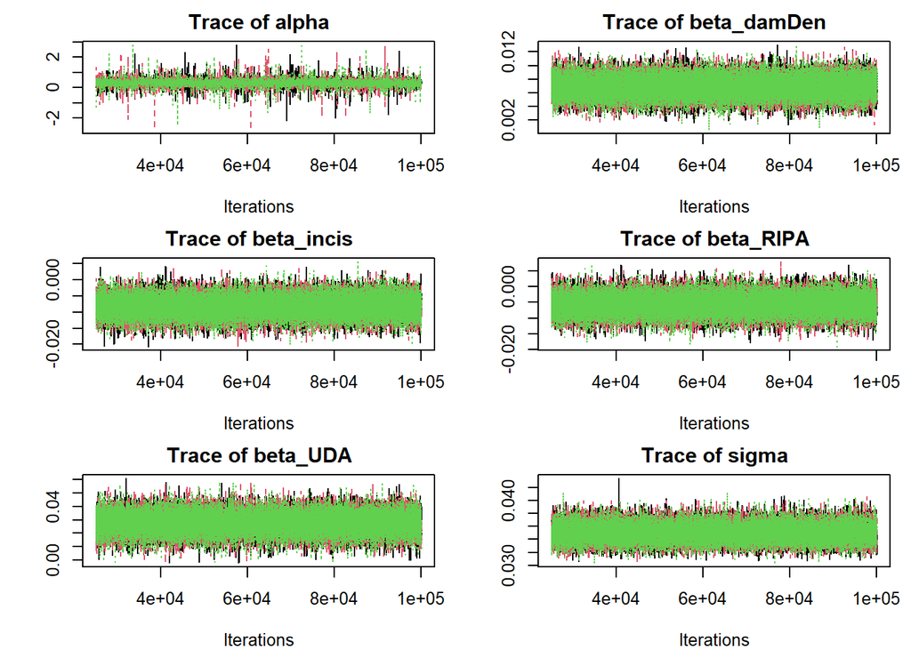

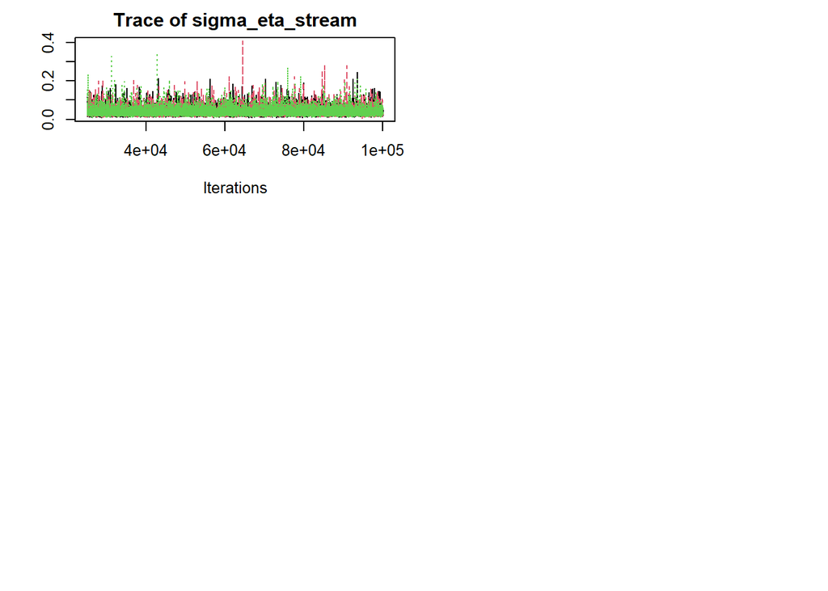

```
Traceplots all look fine.
```

**Posterior predictive plots:**

Predicted NDVI vs observed NDVI

Goal is 1:1 (ish)

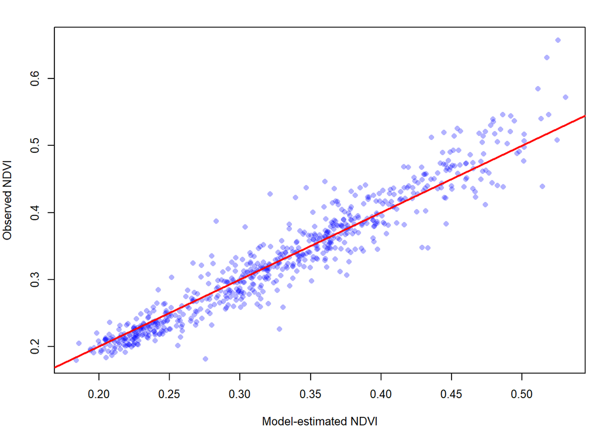

Slope:

```
## m4_mu_NDVI_post
##        1.075919
```

```
1.08 is pretty good
```

**Random effects shrinkage:**

Goal is centered around 0(ish)

1. eta_year; random effect of year on NDVI intercept (n=3)
2. eta_stream; random effect of stream on NDVI intercept (n=6)

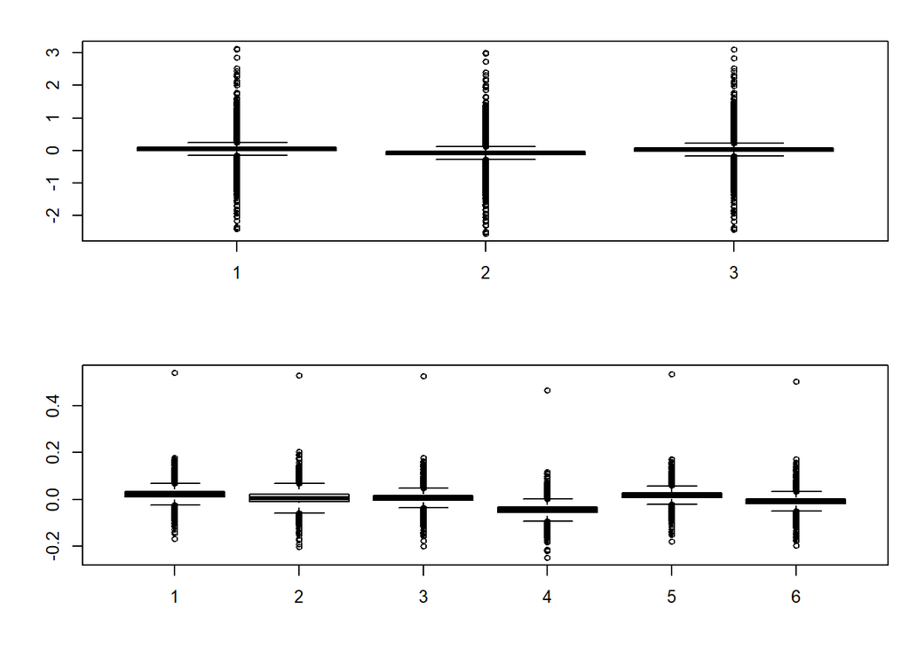

**Prior-posterior overlap:**

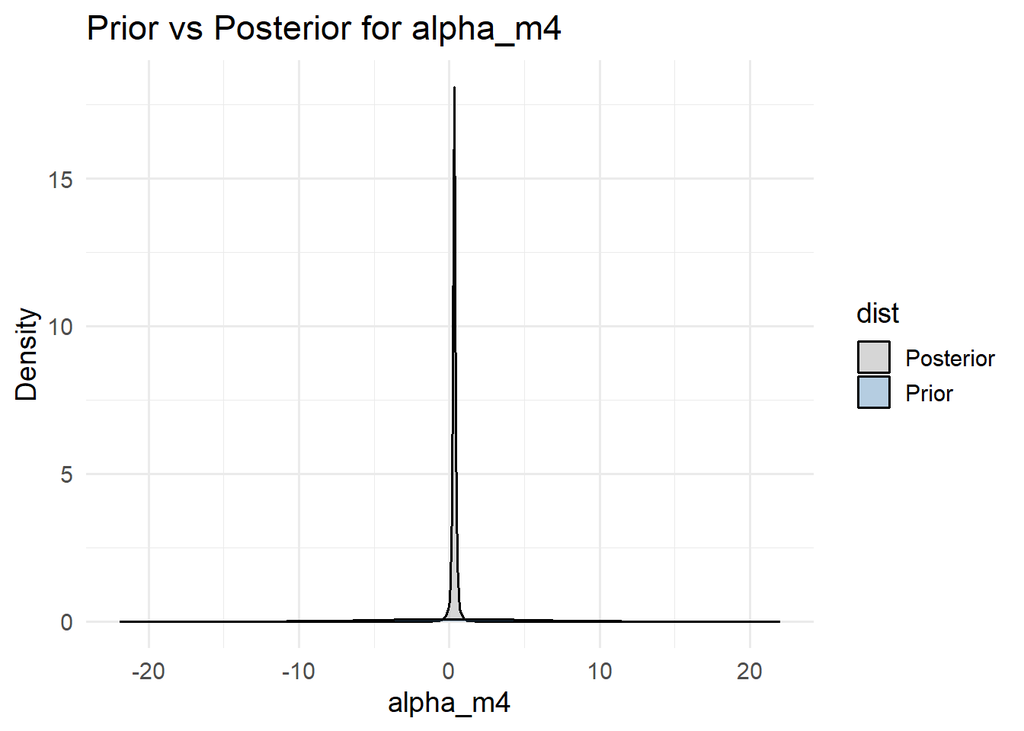

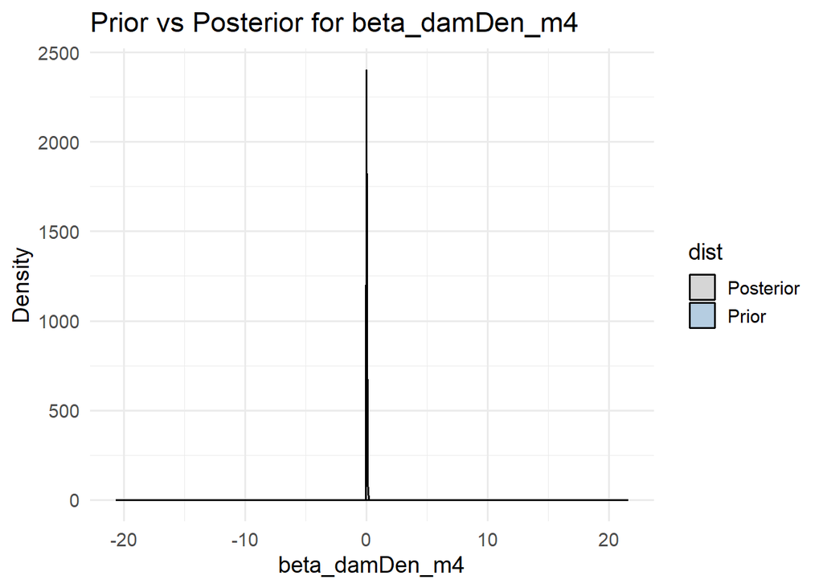

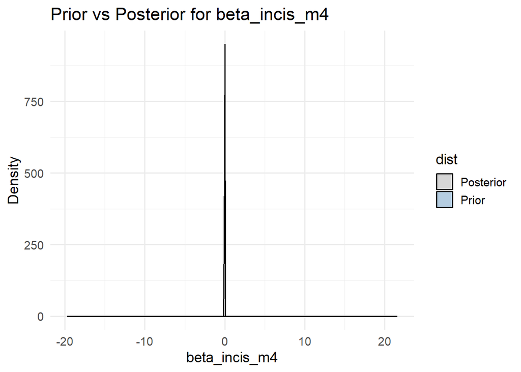

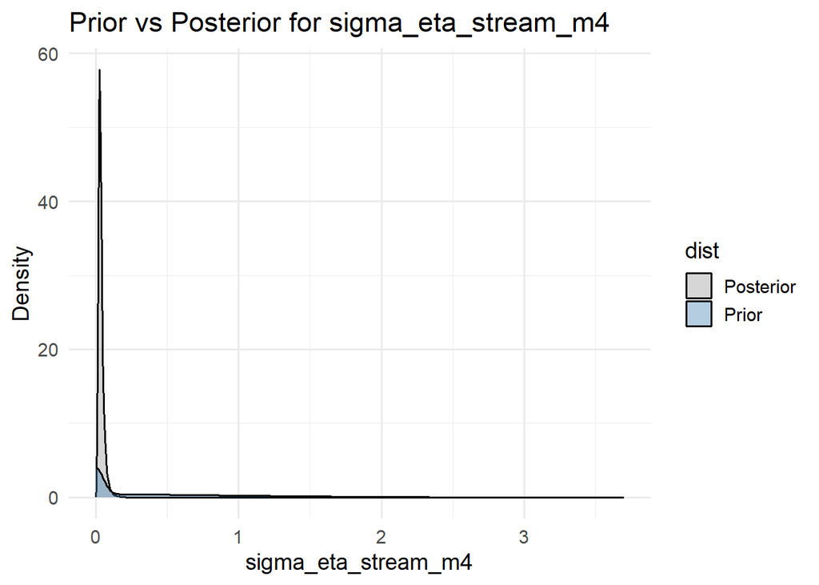

```
PPOs still look good pretty good.
```

**Posterior mean dam density effect**

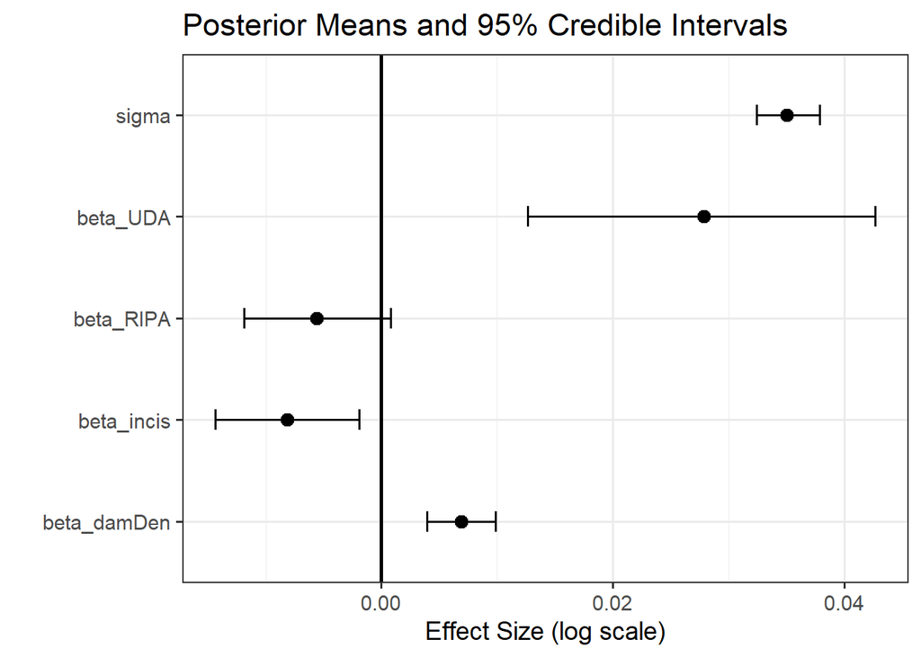

**Posterior Estimates**

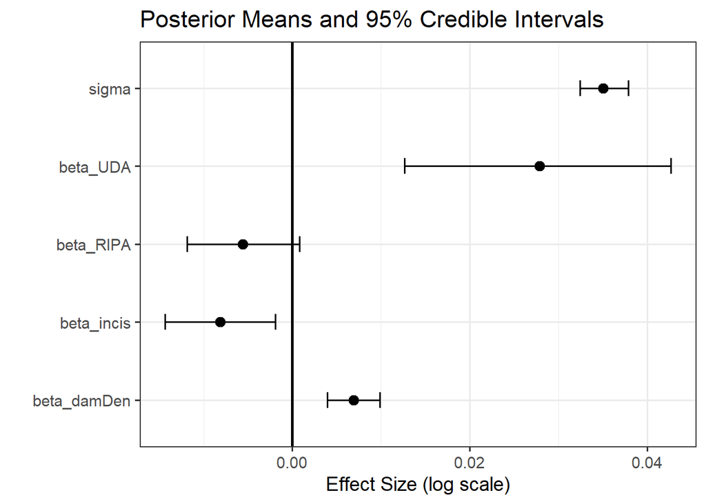

**Effect of 1 SD increase in dam density on NDVI:**

```
##      Min.   1st Qu.    Median      Mean   3rd Qu.      Max.
## 0.0005873 0.0058869 0.0068990 0.0069038 0.0079199 0.0130382
```

```
For a 'typical' stream at mean geomorphic covariate conditions, a 1 SD increase
in dam density is associated with an increase of 0.007 on the raw NDVI scale.

Dam density's influence on NDVI, though "significantly" positive, is very weak.
```

**Estimated effects of geomorphic covariates**

**Effect of 1 SD increase in incision on NDVI:**

```
##      Min.   1st Qu.    Median      Mean   3rd Qu.      Max.
## -0.020666 -0.010280 -0.008159 -0.008154 -0.006035  0.005734
```

```
 For a typical stream at mean covariate conditions, a 1 SD increase in incision (~0.1)
 is associated with a decrease of 0.008 on the raw NDVI scale.

 Again, though "significantly" negative, the effect of incision on NDVI is VERY weak.
```

**Effect of 1 SD increase in riparian area on NDVI:**

```
##      Min.   1st Qu.    Median      Mean   3rd Qu.      Max.
## -0.019042 -0.007771 -0.005603 -0.005590 -0.003421  0.008056
```

```
For a "typcial" stream under mean geomorphic covariate conditions, a 1 SD increase
in riparian area (11000 m^2) is associated with a decrease of 0.006 on the raw
NDVI scale.

This estimate also overlaps zero. Interpretation = no effect of RIPA on NDVI.
```

```
##      Min.   1st Qu.    Median      Mean   3rd Qu.      Max.
## -0.002207  0.022836  0.027978  0.027862  0.032995  0.060960
```

```
For a "typical" stream under mean geomorphic covariate conditions, a 1 SD increase
in Upstream Drainage Area (UDA) (~1300km^2) is associated an increase of 0.028 on
the raw NDVI scale.

Though strongly positive, and the strongest covariate effect, 0.028 is still a very
small change in NDVI.


Take-Away:
Beaver dam density is not noticeably changing the vegetation structure within the
riparian zone, thus mean NDVI at dammed reaches is not meaningfully different than
mean NDVI at paired undammed reaches. Broader-scale hydrologic processes drive
riparian veg greenness in late August.
```

**Partial dependence plots**

Constrain PDP to empirical ranges for SWA and target covariates

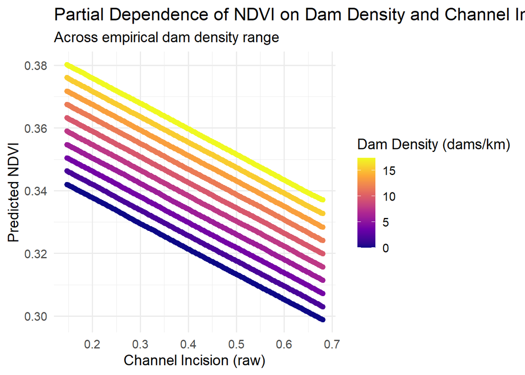

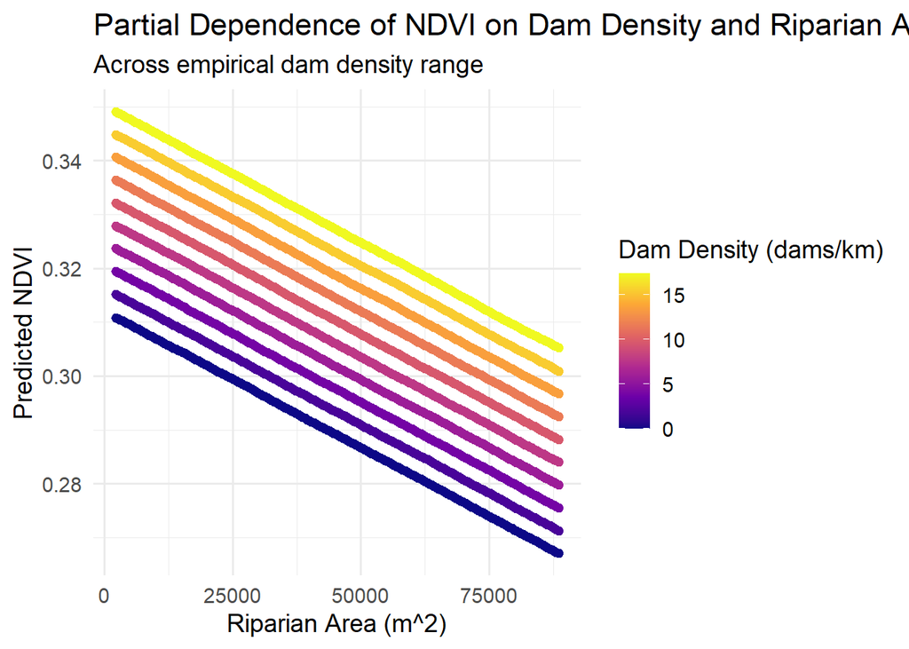

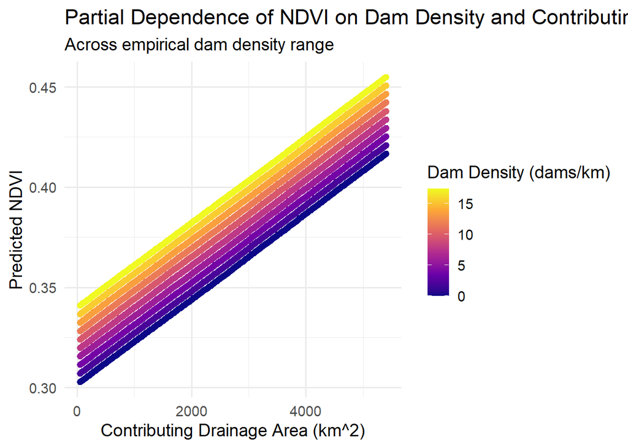

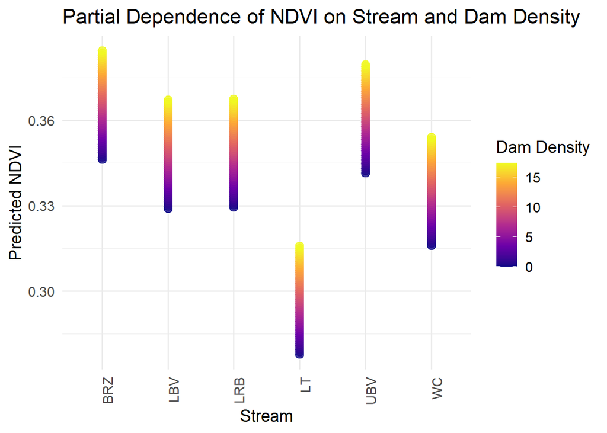

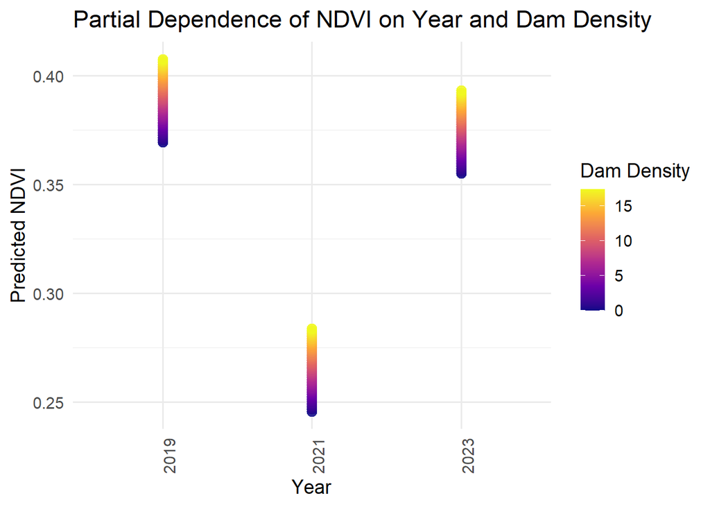

**Model Comparison**

```
## # A tibble: 4 × 2
##   model   WAIC
##   <chr>  <dbl>
## 1 m4    -2323.
## 2 m3    -2318.
## 3 m2    -2315.
## 4 m1    -2308.
```